# Module 140

#### Hemi-module gene counts:

353 probesets in hemi-module A.  
81 probesets in hemi-module B.  
Note: While the mapping of probesets to genes is usually one-to-one, some genes are targeted by multiple probesets, some probesets target multiple genes, and some probesets do not target any genes (i.e., the region of the genome they match is no longer considered genic).

#### Contrast SVE:

Signed variance explained (SVE) provides an indication of how similar a set of fold changes are to a gene module’s weight vector. An SVE value of 0.3, for example, indicates that 30% of the variance explained by the entire module set is accounted for by the module in question. Shown here are the SVE values for this module across a compendium of fold changes (contrasts). Extreme SVE values (e.g., > 0.05) indicate that those contrasts specifically induce (orange dots) or specifically repress (blue dots) this module. Examining the experimental conditions being compared in such contrasts (see tables below the figure) may provide insight into the gene module’s function.

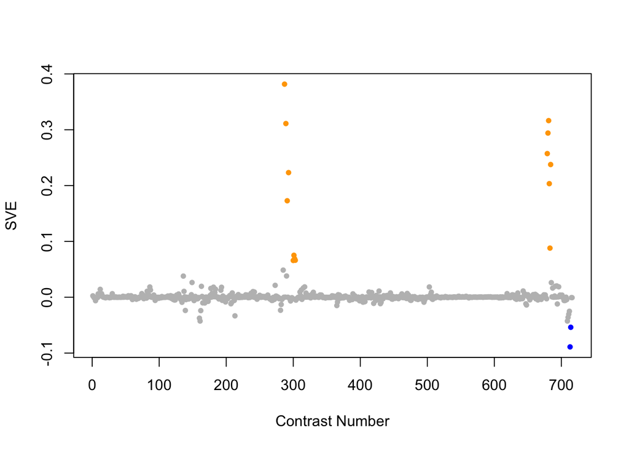

Positive SVE Contrasts:

|  | Contrast.Num | SVE | GEO.GSE | Cond.1 | Cond.2 | Mutation |
| --- | --- | --- | --- | --- | --- | --- |
| GSE41366C.s2t4.vs.s0t4 | 287 | 0.38 | GSE41366 | high_DDVP-continuous_expose-20h_harvest-rep1 | control-continuous_expose-14h_harvest-rep1 |  |
| GSE12298A.s2t1.vs.s0t1 | 681 | 0.32 | GSE12298 | dichlorvos_mid_dose-rep1 | dichlorvos_control-rep1 |  |
| GSE41366C.s2t5.vs.s0t5 | 289 | 0.31 | GSE41366 | high_DDVP-continuous_expose-26h_harvest-rep1 | control-continuous_expose-20h_harvest-rep1 |  |
| GSE12298A.s1t1.vs.s0t1 | 680 | 0.29 | GSE12298 | dichlorvos_low_dose-rep1 | dichlorvos_control-rep1 |  |
| GSE12298A.s3t1.vs.s0t1 | 679 | 0.26 | GSE12298 | dichlorvos_high_dose-rep1 | dichlorvos_control-rep1 |  |
| GSE12298B.s2t1.vs.s0t1 | 684 | 0.24 | GSE12298 | fenamiphos_mid_dose-rep1 | fenamiphos_control-rep1 |  |
| GSE41366C.s2t3.vs.s0t3 | 293 | 0.22 | GSE41366 | high_DDVP-continuous_expose-14h_harvest-rep1 | control-continuous_expose-8h_harvest-rep1 |  |
| GSE12298B.s3t1.vs.s0t1 | 682 | 0.20 | GSE12298 | fenamiphos_high_dose-rep1 | fenamiphos_control-rep1 |  |
| GSE41366C.s2t2.vs.s0t2 | 291 | 0.17 | GSE41366 | high_DDVP-continuous_expose-8h_harvest-rep1 | control-continuous_expose-2h_harvest-rep1 |  |
| GSE12298B.s1t1.vs.s0t1 | 683 | 0.09 | GSE12298 | fenamiphos_low_dose-rep1 | fenamiphos_control-rep1 |  |
| GSE41366C.s2t4.vs.s2t1 | 301 | 0.08 | GSE41366 | high_DDVP-continuous_expose-20h_harvest-rep1 | high_DDVP-continuous_expose-2h_harvest-rep1 |  |
| GSE41366C.s2t5.vs.s2t1 | 302 | 0.07 | GSE41366 | high_DDVP-continuous_expose-26h_harvest-rep1 | high_DDVP-continuous_expose-2h_harvest-rep1 |  |
| GSE41366C.s2t2.vs.s2t1 | 303 | 0.07 | GSE41366 | high_DDVP-continuous_expose-8h_harvest-rep1 | high_DDVP-continuous_expose-2h_harvest-rep1 |  |
| GSE41366C.s2t3.vs.s2t1 | 300 | 0.07 | GSE41366 | high_DDVP-continuous_expose-14h_harvest-rep1 | high_DDVP-continuous_expose-2h_harvest-rep1 |  |

Negative SVE Contrasts:

|  | Contrast.Num | SVE | GEO.GSE | Cond.1 | Cond.2 | Mutation |
| --- | --- | --- | --- | --- | --- | --- |
| GSE11055.s2t4.vs.s2t2 | 713 | -0.09 | GSE11055 | L1 larvae 3 hr after hatching in the absence of food | L1 larvae 0 hr after hatching in the absence of food |  |
| GSE11055.s2t5.vs.s2t2 | 714 | -0.05 | GSE11055 | L1 larvae 6 hr after hatching in the absence of food | L1 larvae 0 hr after hatching in the absence of food |  |
| GSE11055.s2t3.vs.s2t2 | 709 | -0.04 | GSE11055 | L1 larvae 1 hr after hatching in the absence of food | L1 larvae 0 hr after hatching in the absence of food |  |
| GSE47778.s4t2.vs.s3t2 | 161 | -0.04 | GSE47778 | daf-2;daf-16; starvation; replicate 1 | daf-16; starvation; replicate 1 | daf-2;daf-16 vs. daf-16 |
| GSE47778.s2t2.vs.s3t2 | 160 | -0.04 | GSE47778 | daf-2; starvation; replicate 1 | daf-16; starvation; replicate 1 | daf-2 vs. daf-16 |

$~$

#### Contrast SVE, Up-Regulated Genes Only:

Calculating SVE for up-regulated and down-regulated genes separately may be more informative in many cases than projecting the up- and down- gene sets together. This is due to the fact that the weight distribution of many modules is highly skewed, indicating that only one of the hemi-modules may be biologically meaningful (i.e., a set of genes are strongly correlated by only a few genes (or none) are strongly anti-correlated to that set.)

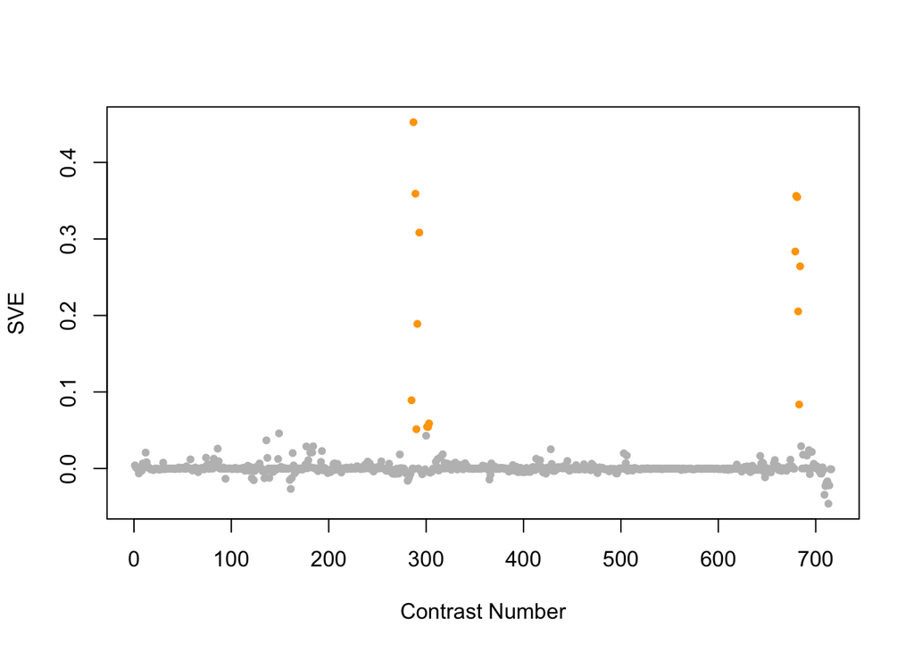

Positive SVE Contrasts:

|  | Contrast.Num | SVE | GEO.GSE | Cond.1 | Cond.2 | Mutation |
| --- | --- | --- | --- | --- | --- | --- |
| GSE41366C.s2t4.vs.s0t4 | 287 | 0.45 | GSE41366 | high_DDVP-continuous_expose-20h_harvest-rep1 | control-continuous_expose-14h_harvest-rep1 |  |
| GSE41366C.s2t5.vs.s0t5 | 289 | 0.36 | GSE41366 | high_DDVP-continuous_expose-26h_harvest-rep1 | control-continuous_expose-20h_harvest-rep1 |  |
| GSE12298A.s1t1.vs.s0t1 | 680 | 0.36 | GSE12298 | dichlorvos_low_dose-rep1 | dichlorvos_control-rep1 |  |
| GSE12298A.s2t1.vs.s0t1 | 681 | 0.35 | GSE12298 | dichlorvos_mid_dose-rep1 | dichlorvos_control-rep1 |  |
| GSE41366C.s2t3.vs.s0t3 | 293 | 0.31 | GSE41366 | high_DDVP-continuous_expose-14h_harvest-rep1 | control-continuous_expose-8h_harvest-rep1 |  |
| GSE12298A.s3t1.vs.s0t1 | 679 | 0.28 | GSE12298 | dichlorvos_high_dose-rep1 | dichlorvos_control-rep1 |  |
| GSE12298B.s2t1.vs.s0t1 | 684 | 0.26 | GSE12298 | fenamiphos_mid_dose-rep1 | fenamiphos_control-rep1 |  |
| GSE12298B.s3t1.vs.s0t1 | 682 | 0.21 | GSE12298 | fenamiphos_high_dose-rep1 | fenamiphos_control-rep1 |  |
| GSE41366C.s2t2.vs.s0t2 | 291 | 0.19 | GSE41366 | high_DDVP-continuous_expose-8h_harvest-rep1 | control-continuous_expose-2h_harvest-rep1 |  |
| GSE41366C.s2t1.vs.s0t1 | 285 | 0.09 | GSE41366 | high_DDVP-continuous_expose-2h_harvest-rep1 | control-continuous_expose-0h_harvest-rep2 |  |
| GSE12298B.s1t1.vs.s0t1 | 683 | 0.08 | GSE12298 | fenamiphos_low_dose-rep1 | fenamiphos_control-rep1 |  |
| GSE41366C.s2t2.vs.s2t1 | 303 | 0.06 | GSE41366 | high_DDVP-continuous_expose-8h_harvest-rep1 | high_DDVP-continuous_expose-2h_harvest-rep1 |  |
| GSE41366C.s2t4.vs.s2t1 | 301 | 0.05 | GSE41366 | high_DDVP-continuous_expose-20h_harvest-rep1 | high_DDVP-continuous_expose-2h_harvest-rep1 |  |
| GSE41366C.s2t5.vs.s2t1 | 302 | 0.05 | GSE41366 | high_DDVP-continuous_expose-26h_harvest-rep1 | high_DDVP-continuous_expose-2h_harvest-rep1 |  |
| GSE41366C.s1t5.vs.s0t5 | 290 | 0.05 | GSE41366 | low_DDVP-continuous_expose-26h_harvest-rep1 | control-continuous_expose-20h_harvest-rep1 |  |

Negative SVE Contrasts:

|  | Contrast.Num | SVE | GEO.GSE | Cond.1 | Cond.2 | Mutation |
| --- | --- | --- | --- | --- | --- | --- |
| GSE11055.s2t4.vs.s2t2 | 713 | -0.05 | GSE11055 | L1 larvae 3 hr after hatching in the absence of food | L1 larvae 0 hr after hatching in the absence of food |  |
| GSE11055.s2t3.vs.s2t2 | 709 | -0.03 | GSE11055 | L1 larvae 1 hr after hatching in the absence of food | L1 larvae 0 hr after hatching in the absence of food |  |
| GSE47778.s4t2.vs.s3t2 | 161 | -0.03 | GSE47778 | daf-2;daf-16; starvation; replicate 1 | daf-16; starvation; replicate 1 | daf-2;daf-16 vs. daf-16 |
| GSE11055.s2t6.vs.s2t2 | 710 | -0.02 | GSE11055 | L1 larvae 12 hr after hatching in the absence of food | L1 larvae 0 hr after hatching in the absence of food |  |
| GSE11055.s2t5.vs.s2t2 | 714 | -0.02 | GSE11055 | L1 larvae 6 hr after hatching in the absence of food | L1 larvae 0 hr after hatching in the absence of food |  |

$~$

#### Contrast SVE, Down-Regulated Genes Only:

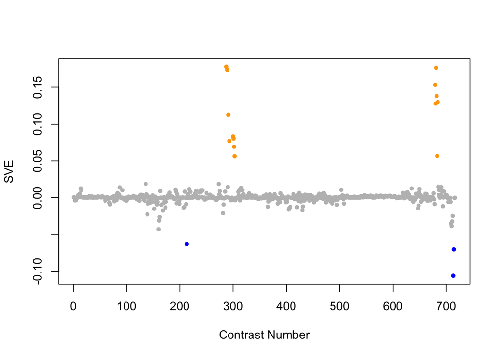

Positive SVE Contrasts:

|  | Contrast.Num | SVE | GEO.GSE | Cond.1 | Cond.2 | Mutation |
| --- | --- | --- | --- | --- | --- | --- |
| GSE41366C.s2t4.vs.s0t4 | 287 | 0.18 | GSE41366 | high_DDVP-continuous_expose-20h_harvest-rep1 | control-continuous_expose-14h_harvest-rep1 |  |
| GSE12298A.s2t1.vs.s0t1 | 681 | 0.18 | GSE12298 | dichlorvos_mid_dose-rep1 | dichlorvos_control-rep1 |  |
| GSE41366C.s2t5.vs.s0t5 | 289 | 0.17 | GSE41366 | high_DDVP-continuous_expose-26h_harvest-rep1 | control-continuous_expose-20h_harvest-rep1 |  |
| GSE12298A.s3t1.vs.s0t1 | 679 | 0.15 | GSE12298 | dichlorvos_high_dose-rep1 | dichlorvos_control-rep1 |  |
| GSE12298B.s3t1.vs.s0t1 | 682 | 0.14 | GSE12298 | fenamiphos_high_dose-rep1 | fenamiphos_control-rep1 |  |
| GSE12298B.s2t1.vs.s0t1 | 684 | 0.13 | GSE12298 | fenamiphos_mid_dose-rep1 | fenamiphos_control-rep1 |  |
| GSE12298A.s1t1.vs.s0t1 | 680 | 0.13 | GSE12298 | dichlorvos_low_dose-rep1 | dichlorvos_control-rep1 |  |
| GSE41366C.s2t2.vs.s0t2 | 291 | 0.11 | GSE41366 | high_DDVP-continuous_expose-8h_harvest-rep1 | control-continuous_expose-2h_harvest-rep1 |  |
| GSE41366C.s2t3.vs.s2t1 | 300 | 0.08 | GSE41366 | high_DDVP-continuous_expose-14h_harvest-rep1 | high_DDVP-continuous_expose-2h_harvest-rep1 |  |
| GSE41366C.s2t4.vs.s2t1 | 301 | 0.08 | GSE41366 | high_DDVP-continuous_expose-20h_harvest-rep1 | high_DDVP-continuous_expose-2h_harvest-rep1 |  |
| GSE41366C.s2t3.vs.s0t3 | 293 | 0.08 | GSE41366 | high_DDVP-continuous_expose-14h_harvest-rep1 | control-continuous_expose-8h_harvest-rep1 |  |
| GSE41366C.s2t5.vs.s2t1 | 302 | 0.07 | GSE41366 | high_DDVP-continuous_expose-26h_harvest-rep1 | high_DDVP-continuous_expose-2h_harvest-rep1 |  |
| GSE12298B.s1t1.vs.s0t1 | 683 | 0.06 | GSE12298 | fenamiphos_low_dose-rep1 | fenamiphos_control-rep1 |  |
| GSE41366C.s2t2.vs.s2t1 | 303 | 0.06 | GSE41366 | high_DDVP-continuous_expose-8h_harvest-rep1 | high_DDVP-continuous_expose-2h_harvest-rep1 |  |

Negative SVE Contrasts:

|  | Contrast.Num | SVE | GEO.GSE | Cond.1 | Cond.2 | Mutation |
| --- | --- | --- | --- | --- | --- | --- |
| GSE11055.s2t4.vs.s2t2 | 713 | -0.11 | GSE11055 | L1 larvae 3 hr after hatching in the absence of food | L1 larvae 0 hr after hatching in the absence of food |  |
| GSE11055.s2t5.vs.s2t2 | 714 | -0.07 | GSE11055 | L1 larvae 6 hr after hatching in the absence of food | L1 larvae 0 hr after hatching in the absence of food |  |
| GSE42689.s4t1.vs.s2t1 | 213 | -0.06 | GSE42689 | mlk-1 fed 1 | mek-1 fed 1 |  |
| GSE47778.s2t2.vs.s3t2 | 160 | -0.04 | GSE47778 | daf-2; starvation; replicate 1 | daf-16; starvation; replicate 1 | daf-2 vs. daf-16 |
| GSE11055.s2t6.vs.s2t2 | 710 | -0.04 | GSE11055 | L1 larvae 12 hr after hatching in the absence of food | L1 larvae 0 hr after hatching in the absence of food |  |

$~$

$~$

#### GO Term Enrichment:

This analysis tests each hemi-module for enrichment of specific GO terms. Only gene-level annotations (e.g., as would be found on the gene’s page in Wormbase) are tested - the hierarchical structure of the GO ontology is not taken into account.

*Note: At least the top two most enriched terms from each GO domain (BP/MF/CC) are shown, even when not statistically significant.*

##### Enriched GO terms: Hemi-module A

| ID | GO.Term | GO Domain | Raw p-value | Adj p-value |
| --- | --- | --- | --- | --- |
| [GO_0060298](http://amigo.geneontology.org/amigo/term/GO:0060298) | positive regulation of sarcomere organization | BP | 3.52e-12 | 1.28e-08 |
| [GO_0007229](http://amigo.geneontology.org/amigo/term/GO:0007229) | integrin-mediated signaling pathway | BP | 2.23e-08 | 4.06e-05 |
| [GO_0060279](http://amigo.geneontology.org/amigo/term/GO:0060279) | positive regulation of ovulation | BP | 8.29e-08 | 1.01e-04 |
| [GO_0046716](http://amigo.geneontology.org/amigo/term/GO:0046716) | muscle cell cellular homeostasis | BP | 5.91e-07 | 5.38e-04 |
| [GO_0040017](http://amigo.geneontology.org/amigo/term/GO:0040017) | positive regulation of locomotion | BP | 5.21e-06 | 3.18e-03 |
| [GO_1904901](http://amigo.geneontology.org/amigo/term/GO:1904901) | positive regulation of myosin II filament organization | BP | 5.24e-06 | 3.18e-03 |
| [GO_0007155](http://amigo.geneontology.org/amigo/term/GO:0007155) | cell adhesion | BP | 8.44e-06 | 4.39e-03 |
| [GO_0007005](http://amigo.geneontology.org/amigo/term/GO:0007005) | mitochondrion organization | BP | 1.63e-05 | 7.43e-03 |
| [GO_0055002](http://amigo.geneontology.org/amigo/term/GO:0055002) | striated muscle cell development | BP | 2.07e-05 | 8.38e-03 |
| [GO_0030239](http://amigo.geneontology.org/amigo/term/GO:0030239) | myofibril assembly | BP | 5.11e-05 | 1.55e-02 |
| [GO_0045987](http://amigo.geneontology.org/amigo/term/GO:0045987) | positive regulation of smooth muscle contraction | BP | 5.11e-05 | 1.55e-02 |
| [GO_0045989](http://amigo.geneontology.org/amigo/term/GO:0045989) | positive regulation of striated muscle contraction | BP | 5.11e-05 | 1.55e-02 |
| [GO_0042059](http://amigo.geneontology.org/amigo/term/GO:0042059) | negative regulation of epidermal growth factor receptor signaling pathway | BP | 1.01e-04 | 2.83e-02 |
| [GO_0071688](http://amigo.geneontology.org/amigo/term/GO:0071688) | striated muscle myosin thick filament assembly | BP | 1.74e-04 | 4.53e-02 |
| [GO_0010447](http://amigo.geneontology.org/amigo/term/GO:0010447) | response to acidic pH | BP | 3.03e-04 | 7.36e-02 |
| [GO_0072327](http://amigo.geneontology.org/amigo/term/GO:0072327) | vulval cell fate specification | BP | 4.07e-04 | 9.28e-02 |
| [GO_0051015](http://amigo.geneontology.org/amigo/term/GO:0051015) | actin filament binding | MF | 3.50e-12 | 7.15e-09 |
| [GO_0003779](http://amigo.geneontology.org/amigo/term/GO:0003779) | actin binding | MF | 9.16e-12 | 9.36e-09 |
| [GO_0005178](http://amigo.geneontology.org/amigo/term/GO:0005178) | integrin binding | MF | 5.24e-06 | 3.57e-03 |
| [GO_0017022](http://amigo.geneontology.org/amigo/term/GO:0017022) | myosin binding | MF | 1.74e-04 | 8.90e-02 |
| [GO_0031430](http://amigo.geneontology.org/amigo/term/GO:0031430) | M band | CC | 3.17e-19 | 2.94e-16 |
| [GO_0055120](http://amigo.geneontology.org/amigo/term/GO:0055120) | striated muscle dense body | CC | 1.98e-15 | 9.21e-13 |
| [GO_0005925](http://amigo.geneontology.org/amigo/term/GO:0005925) | focal adhesion | CC | 5.79e-13 | 1.79e-10 |
| [GO_0009925](http://amigo.geneontology.org/amigo/term/GO:0009925) | basal plasma membrane | CC | 1.77e-06 | 4.11e-04 |
| [GO_0008305](http://amigo.geneontology.org/amigo/term/GO:0008305) | integrin complex | CC | 2.07e-05 | 3.84e-03 |
| [GO_0030016](http://amigo.geneontology.org/amigo/term/GO:0030016) | myofibril | CC | 5.70e-05 | 8.81e-03 |
| [GO_0001725](http://amigo.geneontology.org/amigo/term/GO:0001725) | stress fiber | CC | 1.01e-04 | 1.34e-02 |
| [GO_0015629](http://amigo.geneontology.org/amigo/term/GO:0015629) | actin cytoskeleton | CC | 2.28e-04 | 2.64e-02 |
| [GO_0030018](http://amigo.geneontology.org/amigo/term/GO:0030018) | Z disc | CC | 2.75e-04 | 2.84e-02 |
| [GO_0005865](http://amigo.geneontology.org/amigo/term/GO:0005865) | striated muscle thin filament | CC | 4.07e-04 | 3.44e-02 |
| [GO_0031672](http://amigo.geneontology.org/amigo/term/GO:0031672) | A band | CC | 4.07e-04 | 3.44e-02 |
| [GO_0005634](http://amigo.geneontology.org/amigo/term/GO:0005634) | nucleus | CC | 6.80e-04 | 5.20e-02 |
| [GO_0030017](http://amigo.geneontology.org/amigo/term/GO:0030017) | sarcomere | CC | 7.28e-04 | 5.20e-02 |
| [GO_0005912](http://amigo.geneontology.org/amigo/term/GO:0005912) | adherens junction | CC | 8.55e-04 | 5.56e-02 |
| [GO_0042643](http://amigo.geneontology.org/amigo/term/GO:0042643) | actomyosin, actin portion | CC | 8.99e-04 | 5.56e-02 |
| [GO_0030054](http://amigo.geneontology.org/amigo/term/GO:0030054) | cell junction | CC | 1.58e-03 | 9.17e-02 |

##### Enriched GO terms: Hemi-module B

| ID | GO.Term | GO Domain | Raw p-value | Adj p-value |
| --- | --- | --- | --- | --- |
| [GO_0006629](http://amigo.geneontology.org/amigo/term/GO:0006629) | lipid metabolic process | BP | 1.69e-04 | 6.15e-01 |
| [GO_0016042](http://amigo.geneontology.org/amigo/term/GO:0016042) | lipid catabolic process | BP | 1.99e-03 | 9.99e-01 |
| [GO_0016787](http://amigo.geneontology.org/amigo/term/GO:0016787) | hydrolase activity | MF | 3.57e-04 | 7.29e-01 |
| [GO_0003837](http://amigo.geneontology.org/amigo/term/GO:0003837) | beta-ureidopropionase activity | MF | 4.32e-03 | 1.00e+00 |
| [GO_0055120](http://amigo.geneontology.org/amigo/term/GO:0055120) | striated muscle dense body | CC | 7.10e-04 | 3.31e-01 |
| [GO_0005634](http://amigo.geneontology.org/amigo/term/GO:0005634) | nucleus | CC | 7.14e-04 | 3.31e-01 |

$~$

$~$

#### Tissue Enrichment:

This analysis tests each hemi-module for enrichment of genes associated with anatomy terms. Negative enrichment scores indicate fewer hemi-module genes than expected by random chance were associated with the anatomy term in question.

##### Enriched tissues: Hemi-module A

| ID | Anatomy.Term | Definition | Raw p-value | Adj p-value |
| --- | --- | --- | --- | --- |
| [WBbt_0005813](https://wormbase.org/species/all/anatomy_term/WBbt:0005813) | body wall musculature | Longitudinal bands of muscle cells surrounding animal body, with one band running in each quadrant of the body, regulated contraction and relaxation of these muscles cause locomotion. | 1.67e-13 | 4.07e-10 |
| [WBbt_0005798](https://wormbase.org/species/all/anatomy_term/WBbt:0005798) | anal sphincter muscle | a saddle-shaped muscle cell that encircles the intestinal-rectal valve | 1.79e-07 | 2.18e-04 |
| [WBbt_0005821](https://wormbase.org/species/all/anatomy_term/WBbt:0005821) | vulval muscle | muscle associated with hermaphrodite vulva. | 3.65e-07 | 2.96e-04 |
| [WBbt_0004292](https://wormbase.org/species/all/anatomy_term/WBbt:0004292) | anal depressor muscle | a single, H-shaped cell which lies just above the anus and connects the roof of the anal canal to the dorsal bodywall; its contractions act to increase the size of the anal opening by lifting the roof… | 5.17e-07 | 3.15e-04 |

##### Enriched tissues: Hemi-module B

No significant annotations.

$~$

$~$

#### HOMER promoter motif enrichment:

This analysis tests each hemi-module for enrichment of 108 known *C. elegans* transcription factor binding site motifs (see [108 CE motifs](https://katiepod.github.io//all.worm.motifs.html)) using the HOMER (Hypergeometric Optimization of Motif EnRichment) software (see [PMID:20513432](https://pubmed.ncbi.nlm.nih.gov/20513432)). HOMER was run using default parameters on sequences 1 kb upstream of the transcription start site.

##### Motif enrichment: Hemi-module A

Total target sequences = 289  
Total background sequences = 40923  
* - possible false positive

Rank

Motif

P-value

log P-pvalue

% of Targets

% of Background

STD(Bg STD)

Best Match/Details

Motif File

1

[figure not shown]

1e-13

-3.128e+01

23.53%

8.60%

282.6bp (319.0bp)

fos-1/MA1448.1/Jaspar(0.947)  
[More Information](https://katiepod.github.io/HomerResults/m140_a_hemi_genes.txt.out.1kb/homerResults/motif1.info.html) | [Similar Motifs Found](https://katiepod.github.io/HomerResults/m140_a_hemi_genes.txt.out.1kb/homerResults/motif1.similar.html)

[motif file (matrix)](https://katiepod.github.io/HomerResults/m140_a_hemi_genes.txt.out.1kb/homerResults/motif1.motif)

2

[figure not shown]

1e-13

-3.017e+01

33.56%

15.73%

290.8bp (333.6bp)

POL011.1_XCPE1/Jaspar(0.668)  
[More Information](https://katiepod.github.io/HomerResults/m140_a_hemi_genes.txt.out.1kb/homerResults/motif2.info.html) | [Similar Motifs Found](https://katiepod.github.io/HomerResults/m140_a_hemi_genes.txt.out.1kb/homerResults/motif2.similar.html)

[motif file (matrix)](https://katiepod.github.io/HomerResults/m140_a_hemi_genes.txt.out.1kb/homerResults/motif2.motif)

3

[figure not shown]

1e-12

-2.831e+01

24.22%

9.62%

278.4bp (322.6bp)

POL007.1_BREd/Jaspar(0.646)  
[More Information](https://katiepod.github.io/HomerResults/m140_a_hemi_genes.txt.out.1kb/homerResults/motif3.info.html) | [Similar Motifs Found](https://katiepod.github.io/HomerResults/m140_a_hemi_genes.txt.out.1kb/homerResults/motif3.similar.html)

[motif file (matrix)](https://katiepod.github.io/HomerResults/m140_a_hemi_genes.txt.out.1kb/homerResults/motif3.motif)

4 *

[figure not shown]

1e-11

-2.738e+01

19.38%

6.75%

261.5bp (334.4bp)

eor-1/MA0543.1/Jaspar(0.626)  
[More Information](https://katiepod.github.io/HomerResults/m140_a_hemi_genes.txt.out.1kb/homerResults/motif4.info.html) | [Similar Motifs Found](https://katiepod.github.io/HomerResults/m140_a_hemi_genes.txt.out.1kb/homerResults/motif4.similar.html)

[motif file (matrix)](https://katiepod.github.io/HomerResults/m140_a_hemi_genes.txt.out.1kb/homerResults/motif4.motif)

5 *

[figure not shown]

1e-10

-2.486e+01

39.10%

21.62%

288.8bp (324.4bp)

eor-1/MA0543.1/Jaspar(0.768)  
[More Information](https://katiepod.github.io/HomerResults/m140_a_hemi_genes.txt.out.1kb/homerResults/motif5.info.html) | [Similar Motifs Found](https://katiepod.github.io/HomerResults/m140_a_hemi_genes.txt.out.1kb/homerResults/motif5.similar.html)

[motif file (matrix)](https://katiepod.github.io/HomerResults/m140_a_hemi_genes.txt.out.1kb/homerResults/motif5.motif)

6 *

[figure not shown]

1e-10

-2.478e+01

8.30%

1.45%

273.3bp (314.8bp)

blmp-1/MA0537.1/Jaspar(0.632)  
[More Information](https://katiepod.github.io/HomerResults/m140_a_hemi_genes.txt.out.1kb/homerResults/motif6.info.html) | [Similar Motifs Found](https://katiepod.github.io/HomerResults/m140_a_hemi_genes.txt.out.1kb/homerResults/motif6.similar.html)

[motif file (matrix)](https://katiepod.github.io/HomerResults/m140_a_hemi_genes.txt.out.1kb/homerResults/motif6.motif)

7 *

[figure not shown]

1e-10

-2.434e+01

4.84%

0.39%

311.6bp (322.1bp)

CES-1(Homeobox)/cElegans-L1-CES1-ChIP-Seq(modEncode)/Homer(0.552)  
[More Information](https://katiepod.github.io/HomerResults/m140_a_hemi_genes.txt.out.1kb/homerResults/motif7.info.html) | [Similar Motifs Found](https://katiepod.github.io/HomerResults/m140_a_hemi_genes.txt.out.1kb/homerResults/motif7.similar.html)

[motif file (matrix)](https://katiepod.github.io/HomerResults/m140_a_hemi_genes.txt.out.1kb/homerResults/motif7.motif)

8 *

[figure not shown]

1e-10

-2.405e+01

9.69%

2.07%

285.3bp (336.8bp)

POL012.1_TATA-Box/Jaspar(0.811)  
[More Information](https://katiepod.github.io/HomerResults/m140_a_hemi_genes.txt.out.1kb/homerResults/motif8.info.html) | [Similar Motifs Found](https://katiepod.github.io/HomerResults/m140_a_hemi_genes.txt.out.1kb/homerResults/motif8.similar.html)

[motif file (matrix)](https://katiepod.github.io/HomerResults/m140_a_hemi_genes.txt.out.1kb/homerResults/motif8.motif)

9 *

[figure not shown]

1e-9

-2.272e+01

2.77%

0.07%

340.4bp (333.0bp)

PL0003.1_hlh-2::cnd-1/Jaspar(0.611)  
[More Information](https://katiepod.github.io/HomerResults/m140_a_hemi_genes.txt.out.1kb/homerResults/motif9.info.html) | [Similar Motifs Found](https://katiepod.github.io/HomerResults/m140_a_hemi_genes.txt.out.1kb/homerResults/motif9.similar.html)

[motif file (matrix)](https://katiepod.github.io/HomerResults/m140_a_hemi_genes.txt.out.1kb/homerResults/motif9.motif)

10 *

[figure not shown]

1e-9

-2.257e+01

15.22%

5.11%

299.2bp (317.1bp)

POL003.1_GC-box/Jaspar(0.796)  
[More Information](https://katiepod.github.io/HomerResults/m140_a_hemi_genes.txt.out.1kb/homerResults/motif10.info.html) | [Similar Motifs Found](https://katiepod.github.io/HomerResults/m140_a_hemi_genes.txt.out.1kb/homerResults/motif10.similar.html)

[motif file (matrix)](https://katiepod.github.io/HomerResults/m140_a_hemi_genes.txt.out.1kb/homerResults/motif10.motif)

11 *

[figure not shown]

1e-9

-2.225e+01

2.77%

0.08%

296.3bp (278.4bp)

MF0008.1_MADS_class/Jaspar(0.520)  
[More Information](https://katiepod.github.io/HomerResults/m140_a_hemi_genes.txt.out.1kb/homerResults/motif11.info.html) | [Similar Motifs Found](https://katiepod.github.io/HomerResults/m140_a_hemi_genes.txt.out.1kb/homerResults/motif11.similar.html)

[motif file (matrix)](https://katiepod.github.io/HomerResults/m140_a_hemi_genes.txt.out.1kb/homerResults/motif11.motif)

12 *

[figure not shown]

1e-9

-2.219e+01

3.46%

0.17%

256.4bp (313.8bp)

MF0005.1_Forkhead_class/Jaspar(0.667)  
[More Information](https://katiepod.github.io/HomerResults/m140_a_hemi_genes.txt.out.1kb/homerResults/motif12.info.html) | [Similar Motifs Found](https://katiepod.github.io/HomerResults/m140_a_hemi_genes.txt.out.1kb/homerResults/motif12.similar.html)

[motif file (matrix)](https://katiepod.github.io/HomerResults/m140_a_hemi_genes.txt.out.1kb/homerResults/motif12.motif)

13 *

[figure not shown]

1e-9

-2.205e+01

5.88%

0.77%

220.9bp (317.1bp)

pqm-1/MA1703.1/Jaspar(0.671)  
[More Information](https://katiepod.github.io/HomerResults/m140_a_hemi_genes.txt.out.1kb/homerResults/motif13.info.html) | [Similar Motifs Found](https://katiepod.github.io/HomerResults/m140_a_hemi_genes.txt.out.1kb/homerResults/motif13.similar.html)

[motif file (matrix)](https://katiepod.github.io/HomerResults/m140_a_hemi_genes.txt.out.1kb/homerResults/motif13.motif)

14 *

[figure not shown]

1e-9

-2.145e+01

13.15%

4.11%

258.3bp (324.7bp)

nhr-6/MA1451.1/Jaspar(0.649)  
[More Information](https://katiepod.github.io/HomerResults/m140_a_hemi_genes.txt.out.1kb/homerResults/motif14.info.html) | [Similar Motifs Found](https://katiepod.github.io/HomerResults/m140_a_hemi_genes.txt.out.1kb/homerResults/motif14.similar.html)

[motif file (matrix)](https://katiepod.github.io/HomerResults/m140_a_hemi_genes.txt.out.1kb/homerResults/motif14.motif)

15 *

[figure not shown]

1e-9

-2.092e+01

3.11%

0.14%

186.9bp (295.2bp)

daf-16/MA1446.1/Jaspar(0.750)  
[More Information](https://katiepod.github.io/HomerResults/m140_a_hemi_genes.txt.out.1kb/homerResults/motif15.info.html) | [Similar Motifs Found](https://katiepod.github.io/HomerResults/m140_a_hemi_genes.txt.out.1kb/homerResults/motif15.similar.html)

[motif file (matrix)](https://katiepod.github.io/HomerResults/m140_a_hemi_genes.txt.out.1kb/homerResults/motif15.motif)

16 *

[figure not shown]

1e-9

-2.088e+01

4.50%

0.42%

306.7bp (313.1bp)

cebp-1/MA1444.1/Jaspar(0.779)  
[More Information](https://katiepod.github.io/HomerResults/m140_a_hemi_genes.txt.out.1kb/homerResults/motif16.info.html) | [Similar Motifs Found](https://katiepod.github.io/HomerResults/m140_a_hemi_genes.txt.out.1kb/homerResults/motif16.similar.html)

[motif file (matrix)](https://katiepod.github.io/HomerResults/m140_a_hemi_genes.txt.out.1kb/homerResults/motif16.motif)

17 *

[figure not shown]

1e-9

-2.081e+01

4.50%

0.43%

267.1bp (339.6bp)

MF0004.1_Nuclear_Receptor_class/Jaspar(0.631)  
[More Information](https://katiepod.github.io/HomerResults/m140_a_hemi_genes.txt.out.1kb/homerResults/motif17.info.html) | [Similar Motifs Found](https://katiepod.github.io/HomerResults/m140_a_hemi_genes.txt.out.1kb/homerResults/motif17.similar.html)

[motif file (matrix)](https://katiepod.github.io/HomerResults/m140_a_hemi_genes.txt.out.1kb/homerResults/motif17.motif)

18 *

[figure not shown]

1e-8

-1.918e+01

8.65%

2.10%

244.5bp (323.7bp)

PL0003.1_hlh-2::cnd-1/Jaspar(0.738)  
[More Information](https://katiepod.github.io/HomerResults/m140_a_hemi_genes.txt.out.1kb/homerResults/motif18.info.html) | [Similar Motifs Found](https://katiepod.github.io/HomerResults/m140_a_hemi_genes.txt.out.1kb/homerResults/motif18.similar.html)

[motif file (matrix)](https://katiepod.github.io/HomerResults/m140_a_hemi_genes.txt.out.1kb/homerResults/motif18.motif)

19 *

[figure not shown]

1e-8

-1.904e+01

11.07%

3.34%

280.6bp (303.9bp)

cebp-1/MA1444.1/Jaspar(0.609)  
[More Information](https://katiepod.github.io/HomerResults/m140_a_hemi_genes.txt.out.1kb/homerResults/motif19.info.html) | [Similar Motifs Found](https://katiepod.github.io/HomerResults/m140_a_hemi_genes.txt.out.1kb/homerResults/motif19.similar.html)

[motif file (matrix)](https://katiepod.github.io/HomerResults/m140_a_hemi_genes.txt.out.1kb/homerResults/motif19.motif)

20 *

[figure not shown]

1e-8

-1.898e+01

6.57%

1.21%

290.5bp (303.3bp)

POL010.1_DCE_S_III/Jaspar(0.656)  
[More Information](https://katiepod.github.io/HomerResults/m140_a_hemi_genes.txt.out.1kb/homerResults/motif20.info.html) | [Similar Motifs Found](https://katiepod.github.io/HomerResults/m140_a_hemi_genes.txt.out.1kb/homerResults/motif20.similar.html)

[motif file (matrix)](https://katiepod.github.io/HomerResults/m140_a_hemi_genes.txt.out.1kb/homerResults/motif20.motif)

21 *

[figure not shown]

1e-8

-1.882e+01

15.92%

6.23%

303.7bp (325.7bp)

nhr-6/MA1451.1/Jaspar(0.558)  
[More Information](https://katiepod.github.io/HomerResults/m140_a_hemi_genes.txt.out.1kb/homerResults/motif21.info.html) | [Similar Motifs Found](https://katiepod.github.io/HomerResults/m140_a_hemi_genes.txt.out.1kb/homerResults/motif21.similar.html)

[motif file (matrix)](https://katiepod.github.io/HomerResults/m140_a_hemi_genes.txt.out.1kb/homerResults/motif21.motif)

22 *

[figure not shown]

1e-7

-1.771e+01

21.45%

10.26%

303.2bp (320.9bp)

ELT-3(Gata)/cElegans-L1-ELT3-ChIP-Seq(modEncode)/Homer(0.579)  
[More Information](https://katiepod.github.io/HomerResults/m140_a_hemi_genes.txt.out.1kb/homerResults/motif22.info.html) | [Similar Motifs Found](https://katiepod.github.io/HomerResults/m140_a_hemi_genes.txt.out.1kb/homerResults/motif22.similar.html)

[motif file (matrix)](https://katiepod.github.io/HomerResults/m140_a_hemi_genes.txt.out.1kb/homerResults/motif22.motif)

23 *

[figure not shown]

1e-7

-1.761e+01

7.96%

1.94%

254.6bp (324.2bp)

MF0001.1_ETS_class/Jaspar(0.732)  
[More Information](https://katiepod.github.io/HomerResults/m140_a_hemi_genes.txt.out.1kb/homerResults/motif23.info.html) | [Similar Motifs Found](https://katiepod.github.io/HomerResults/m140_a_hemi_genes.txt.out.1kb/homerResults/motif23.similar.html)

[motif file (matrix)](https://katiepod.github.io/HomerResults/m140_a_hemi_genes.txt.out.1kb/homerResults/motif23.motif)

24 *

[figure not shown]

1e-7

-1.737e+01

4.50%

0.58%

240.3bp (285.5bp)

MF0011.1_HMG_class/Jaspar(0.554)  
[More Information](https://katiepod.github.io/HomerResults/m140_a_hemi_genes.txt.out.1kb/homerResults/motif24.info.html) | [Similar Motifs Found](https://katiepod.github.io/HomerResults/m140_a_hemi_genes.txt.out.1kb/homerResults/motif24.similar.html)

[motif file (matrix)](https://katiepod.github.io/HomerResults/m140_a_hemi_genes.txt.out.1kb/homerResults/motif24.motif)

25 *

[figure not shown]

1e-7

-1.679e+01

5.19%

0.85%

278.6bp (297.9bp)

MF0011.1_HMG_class/Jaspar(0.696)  
[More Information](https://katiepod.github.io/HomerResults/m140_a_hemi_genes.txt.out.1kb/homerResults/motif25.info.html) | [Similar Motifs Found](https://katiepod.github.io/HomerResults/m140_a_hemi_genes.txt.out.1kb/homerResults/motif25.similar.html)

[motif file (matrix)](https://katiepod.github.io/HomerResults/m140_a_hemi_genes.txt.out.1kb/homerResults/motif25.motif)

26 *

[figure not shown]

1e-7

-1.666e+01

3.81%

0.41%

274.8bp (303.7bp)

unc-62/MA0918.1/Jaspar(0.642)  
[More Information](https://katiepod.github.io/HomerResults/m140_a_hemi_genes.txt.out.1kb/homerResults/motif26.info.html) | [Similar Motifs Found](https://katiepod.github.io/HomerResults/m140_a_hemi_genes.txt.out.1kb/homerResults/motif26.similar.html)

[motif file (matrix)](https://katiepod.github.io/HomerResults/m140_a_hemi_genes.txt.out.1kb/homerResults/motif26.motif)

27 *

[figure not shown]

1e-6

-1.571e+01

6.92%

1.66%

309.7bp (329.6bp)

POL009.1_DCE_S_II/Jaspar(0.624)  
[More Information](https://katiepod.github.io/HomerResults/m140_a_hemi_genes.txt.out.1kb/homerResults/motif27.info.html) | [Similar Motifs Found](https://katiepod.github.io/HomerResults/m140_a_hemi_genes.txt.out.1kb/homerResults/motif27.similar.html)

[motif file (matrix)](https://katiepod.github.io/HomerResults/m140_a_hemi_genes.txt.out.1kb/homerResults/motif27.motif)

28 *

[figure not shown]

1e-6

-1.447e+01

5.88%

1.32%

279.3bp (309.2bp)

MF0001.1_ETS_class/Jaspar(0.679)  
[More Information](https://katiepod.github.io/HomerResults/m140_a_hemi_genes.txt.out.1kb/homerResults/motif28.info.html) | [Similar Motifs Found](https://katiepod.github.io/HomerResults/m140_a_hemi_genes.txt.out.1kb/homerResults/motif28.similar.html)

[motif file (matrix)](https://katiepod.github.io/HomerResults/m140_a_hemi_genes.txt.out.1kb/homerResults/motif28.motif)

29 *

[figure not shown]

1e-6

-1.440e+01

12.46%

4.97%

304.1bp (319.5bp)

POL008.1_DCE_S_I/Jaspar(0.636)  
[More Information](https://katiepod.github.io/HomerResults/m140_a_hemi_genes.txt.out.1kb/homerResults/motif29.info.html) | [Similar Motifs Found](https://katiepod.github.io/HomerResults/m140_a_hemi_genes.txt.out.1kb/homerResults/motif29.similar.html)

[motif file (matrix)](https://katiepod.github.io/HomerResults/m140_a_hemi_genes.txt.out.1kb/homerResults/motif29.motif)

30 *

[figure not shown]

1e-5

-1.337e+01

5.19%

1.12%

298.5bp (321.6bp)

lin-54/MA1450.1/Jaspar(0.510)  
[More Information](https://katiepod.github.io/HomerResults/m140_a_hemi_genes.txt.out.1kb/homerResults/motif30.info.html) | [Similar Motifs Found](https://katiepod.github.io/HomerResults/m140_a_hemi_genes.txt.out.1kb/homerResults/motif30.similar.html)

[motif file (matrix)](https://katiepod.github.io/HomerResults/m140_a_hemi_genes.txt.out.1kb/homerResults/motif30.motif)

31 *

[figure not shown]

1e-5

-1.334e+01

1.38%

0.02%

111.8bp (367.3bp)

sma-4/MA0925.1/Jaspar(0.552)  
[More Information](https://katiepod.github.io/HomerResults/m140_a_hemi_genes.txt.out.1kb/homerResults/motif31.info.html) | [Similar Motifs Found](https://katiepod.github.io/HomerResults/m140_a_hemi_genes.txt.out.1kb/homerResults/motif31.similar.html)

[motif file (matrix)](https://katiepod.github.io/HomerResults/m140_a_hemi_genes.txt.out.1kb/homerResults/motif31.motif)

32 *

[figure not shown]

1e-4

-9.923e+00

0.69%

0.00%

279.3bp (0.0bp)

SD0002.1_at_AC_acceptor/Jaspar(0.552)  
[More Information](https://katiepod.github.io/HomerResults/m140_a_hemi_genes.txt.out.1kb/homerResults/motif32.info.html) | [Similar Motifs Found](https://katiepod.github.io/HomerResults/m140_a_hemi_genes.txt.out.1kb/homerResults/motif32.similar.html)

[motif file (matrix)](https://katiepod.github.io/HomerResults/m140_a_hemi_genes.txt.out.1kb/homerResults/motif32.motif)

33 *

[figure not shown]

1e-3

-7.601e+00

2.77%

0.61%

179.0bp (293.1bp)

unc-62/MA0918.1/Jaspar(0.537)  
[More Information](https://katiepod.github.io/HomerResults/m140_a_hemi_genes.txt.out.1kb/homerResults/motif33.info.html) | [Similar Motifs Found](https://katiepod.github.io/HomerResults/m140_a_hemi_genes.txt.out.1kb/homerResults/motif33.similar.html)

[motif file (matrix)](https://katiepod.github.io/HomerResults/m140_a_hemi_genes.txt.out.1kb/homerResults/motif33.motif)

34 *

[figure not shown]

1e-1

-4.035e+00

5.88%

3.31%

201.8bp (314.4bp)

PL0002.1_hlh-2::hlh-3/Jaspar(0.593)  
[More Information](https://katiepod.github.io/HomerResults/m140_a_hemi_genes.txt.out.1kb/homerResults/motif34.info.html) | [Similar Motifs Found](https://katiepod.github.io/HomerResults/m140_a_hemi_genes.txt.out.1kb/homerResults/motif34.similar.html)

[motif file (matrix)](https://katiepod.github.io/HomerResults/m140_a_hemi_genes.txt.out.1kb/homerResults/motif34.motif)

##### Motif enrichment: Hemi-module B

Total target sequences = 70  
Total background sequences = 40628  
* - possible false positive

Rank

Motif

P-value

log P-pvalue

% of Targets

% of Background

STD(Bg STD)

Best Match/Details

Motif File

1 *

[figure not shown]

1e-11

-2.693e+01

17.14%

0.89%

291.7bp (287.1bp)

pha-4/MA0546.1/Jaspar(0.534)  
[More Information](https://katiepod.github.io/HomerResults/m140_b_hemi_genes.txt.out.1kb/homerResults/motif1.info.html) | [Similar Motifs Found](https://katiepod.github.io/HomerResults/m140_b_hemi_genes.txt.out.1kb/homerResults/motif1.similar.html)

[motif file (matrix)](https://katiepod.github.io/HomerResults/m140_b_hemi_genes.txt.out.1kb/homerResults/motif1.motif)

2 *

[figure not shown]

1e-10

-2.379e+01

11.43%

0.29%

168.4bp (305.8bp)

fos-1/MA1448.1/Jaspar(0.525)  
[More Information](https://katiepod.github.io/HomerResults/m140_b_hemi_genes.txt.out.1kb/homerResults/motif2.info.html) | [Similar Motifs Found](https://katiepod.github.io/HomerResults/m140_b_hemi_genes.txt.out.1kb/homerResults/motif2.similar.html)

[motif file (matrix)](https://katiepod.github.io/HomerResults/m140_b_hemi_genes.txt.out.1kb/homerResults/motif2.motif)

3 *

[figure not shown]

1e-9

-2.226e+01

18.57%

1.70%

314.6bp (315.0bp)

MF0005.1_Forkhead_class/Jaspar(0.716)  
[More Information](https://katiepod.github.io/HomerResults/m140_b_hemi_genes.txt.out.1kb/homerResults/motif3.info.html) | [Similar Motifs Found](https://katiepod.github.io/HomerResults/m140_b_hemi_genes.txt.out.1kb/homerResults/motif3.similar.html)

[motif file (matrix)](https://katiepod.github.io/HomerResults/m140_b_hemi_genes.txt.out.1kb/homerResults/motif3.motif)

4 *

[figure not shown]

1e-9

-2.182e+01

12.86%

0.57%

305.2bp (296.6bp)

MF0011.1_HMG_class/Jaspar(0.484)  
[More Information](https://katiepod.github.io/HomerResults/m140_b_hemi_genes.txt.out.1kb/homerResults/motif4.info.html) | [Similar Motifs Found](https://katiepod.github.io/HomerResults/m140_b_hemi_genes.txt.out.1kb/homerResults/motif4.similar.html)

[motif file (matrix)](https://katiepod.github.io/HomerResults/m140_b_hemi_genes.txt.out.1kb/homerResults/motif4.motif)

5 *

[figure not shown]

1e-9

-2.163e+01

18.57%

1.80%

307.2bp (329.0bp)

ceh-22/MA0264.1/Jaspar(0.673)  
[More Information](https://katiepod.github.io/HomerResults/m140_b_hemi_genes.txt.out.1kb/homerResults/motif5.info.html) | [Similar Motifs Found](https://katiepod.github.io/HomerResults/m140_b_hemi_genes.txt.out.1kb/homerResults/motif5.similar.html)

[motif file (matrix)](https://katiepod.github.io/HomerResults/m140_b_hemi_genes.txt.out.1kb/homerResults/motif5.motif)

6 *

[figure not shown]

1e-9

-2.147e+01

24.29%

3.65%

285.5bp (323.1bp)

MF0001.1_ETS_class/Jaspar(0.648)  
[More Information](https://katiepod.github.io/HomerResults/m140_b_hemi_genes.txt.out.1kb/homerResults/motif6.info.html) | [Similar Motifs Found](https://katiepod.github.io/HomerResults/m140_b_hemi_genes.txt.out.1kb/homerResults/motif6.similar.html)

[motif file (matrix)](https://katiepod.github.io/HomerResults/m140_b_hemi_genes.txt.out.1kb/homerResults/motif6.motif)

7 *

[figure not shown]

1e-9

-2.146e+01

21.43%

2.67%

262.2bp (317.8bp)

nhr-6/MA1451.1/Jaspar(0.876)  
[More Information](https://katiepod.github.io/HomerResults/m140_b_hemi_genes.txt.out.1kb/homerResults/motif7.info.html) | [Similar Motifs Found](https://katiepod.github.io/HomerResults/m140_b_hemi_genes.txt.out.1kb/homerResults/motif7.similar.html)

[motif file (matrix)](https://katiepod.github.io/HomerResults/m140_b_hemi_genes.txt.out.1kb/homerResults/motif7.motif)

8 *

[figure not shown]

1e-9

-2.138e+01

20.00%

2.24%

318.4bp (300.7bp)

fkh-9/MA1440.1/Jaspar(0.636)  
[More Information](https://katiepod.github.io/HomerResults/m140_b_hemi_genes.txt.out.1kb/homerResults/motif8.info.html) | [Similar Motifs Found](https://katiepod.github.io/HomerResults/m140_b_hemi_genes.txt.out.1kb/homerResults/motif8.similar.html)

[motif file (matrix)](https://katiepod.github.io/HomerResults/m140_b_hemi_genes.txt.out.1kb/homerResults/motif8.motif)

9 *

[figure not shown]

1e-8

-2.013e+01

15.71%

1.28%

226.4bp (310.1bp)

POL006.1_BREu/Jaspar(0.639)  
[More Information](https://katiepod.github.io/HomerResults/m140_b_hemi_genes.txt.out.1kb/homerResults/motif9.info.html) | [Similar Motifs Found](https://katiepod.github.io/HomerResults/m140_b_hemi_genes.txt.out.1kb/homerResults/motif9.similar.html)

[motif file (matrix)](https://katiepod.github.io/HomerResults/m140_b_hemi_genes.txt.out.1kb/homerResults/motif9.motif)

10 *

[figure not shown]

1e-8

-1.964e+01

21.43%

3.06%

205.5bp (312.8bp)

SD0003.1_at_AC_acceptor/Jaspar(0.605)  
[More Information](https://katiepod.github.io/HomerResults/m140_b_hemi_genes.txt.out.1kb/homerResults/motif10.info.html) | [Similar Motifs Found](https://katiepod.github.io/HomerResults/m140_b_hemi_genes.txt.out.1kb/homerResults/motif10.similar.html)

[motif file (matrix)](https://katiepod.github.io/HomerResults/m140_b_hemi_genes.txt.out.1kb/homerResults/motif10.motif)

11 *

[figure not shown]

1e-8

-1.862e+01

14.29%

1.13%

225.7bp (311.4bp)

atf-7/MA1438.1/Jaspar(0.602)  
[More Information](https://katiepod.github.io/HomerResults/m140_b_hemi_genes.txt.out.1kb/homerResults/motif11.info.html) | [Similar Motifs Found](https://katiepod.github.io/HomerResults/m140_b_hemi_genes.txt.out.1kb/homerResults/motif11.similar.html)

[motif file (matrix)](https://katiepod.github.io/HomerResults/m140_b_hemi_genes.txt.out.1kb/homerResults/motif11.motif)

12 *

[figure not shown]

1e-8

-1.842e+01

11.43%

0.58%

306.8bp (314.5bp)

skn-1/MA0547.1/Jaspar(0.700)  
[More Information](https://katiepod.github.io/HomerResults/m140_b_hemi_genes.txt.out.1kb/homerResults/motif12.info.html) | [Similar Motifs Found](https://katiepod.github.io/HomerResults/m140_b_hemi_genes.txt.out.1kb/homerResults/motif12.similar.html)

[motif file (matrix)](https://katiepod.github.io/HomerResults/m140_b_hemi_genes.txt.out.1kb/homerResults/motif12.motif)

13 *

[figure not shown]

1e-7

-1.833e+01

20.00%

2.86%

247.4bp (301.8bp)

POL012.1_TATA-Box/Jaspar(0.582)  
[More Information](https://katiepod.github.io/HomerResults/m140_b_hemi_genes.txt.out.1kb/homerResults/motif13.info.html) | [Similar Motifs Found](https://katiepod.github.io/HomerResults/m140_b_hemi_genes.txt.out.1kb/homerResults/motif13.similar.html)

[motif file (matrix)](https://katiepod.github.io/HomerResults/m140_b_hemi_genes.txt.out.1kb/homerResults/motif13.motif)

14 *

[figure not shown]

1e-7

-1.730e+01

11.43%

0.67%

233.6bp (295.0bp)

POL001.1_MTE/Jaspar(0.489)  
[More Information](https://katiepod.github.io/HomerResults/m140_b_hemi_genes.txt.out.1kb/homerResults/motif14.info.html) | [Similar Motifs Found](https://katiepod.github.io/HomerResults/m140_b_hemi_genes.txt.out.1kb/homerResults/motif14.similar.html)

[motif file (matrix)](https://katiepod.github.io/HomerResults/m140_b_hemi_genes.txt.out.1kb/homerResults/motif14.motif)

15 *

[figure not shown]

1e-7

-1.722e+01

14.29%

1.32%

280.5bp (322.9bp)

PL0015.1_hlh-2::hlh-14/Jaspar(0.576)  
[More Information](https://katiepod.github.io/HomerResults/m140_b_hemi_genes.txt.out.1kb/homerResults/motif15.info.html) | [Similar Motifs Found](https://katiepod.github.io/HomerResults/m140_b_hemi_genes.txt.out.1kb/homerResults/motif15.similar.html)

[motif file (matrix)](https://katiepod.github.io/HomerResults/m140_b_hemi_genes.txt.out.1kb/homerResults/motif15.motif)

16 *

[figure not shown]

1e-7

-1.692e+01

8.57%

0.26%

240.0bp (284.5bp)

nhr-6/MA1451.1/Jaspar(0.580)  
[More Information](https://katiepod.github.io/HomerResults/m140_b_hemi_genes.txt.out.1kb/homerResults/motif16.info.html) | [Similar Motifs Found](https://katiepod.github.io/HomerResults/m140_b_hemi_genes.txt.out.1kb/homerResults/motif16.similar.html)

[motif file (matrix)](https://katiepod.github.io/HomerResults/m140_b_hemi_genes.txt.out.1kb/homerResults/motif16.motif)

17 *

[figure not shown]

1e-7

-1.614e+01

5.71%

0.05%

234.5bp (185.3bp)

MF0011.1_HMG_class/Jaspar(0.617)  
[More Information](https://katiepod.github.io/HomerResults/m140_b_hemi_genes.txt.out.1kb/homerResults/motif17.info.html) | [Similar Motifs Found](https://katiepod.github.io/HomerResults/m140_b_hemi_genes.txt.out.1kb/homerResults/motif17.similar.html)

[motif file (matrix)](https://katiepod.github.io/HomerResults/m140_b_hemi_genes.txt.out.1kb/homerResults/motif17.motif)

18 *

[figure not shown]

1e-6

-1.418e+01

7.14%

0.23%

231.5bp (284.8bp)

POL009.1_DCE_S_II/Jaspar(0.627)  
[More Information](https://katiepod.github.io/HomerResults/m140_b_hemi_genes.txt.out.1kb/homerResults/motif18.info.html) | [Similar Motifs Found](https://katiepod.github.io/HomerResults/m140_b_hemi_genes.txt.out.1kb/homerResults/motif18.similar.html)

[motif file (matrix)](https://katiepod.github.io/HomerResults/m140_b_hemi_genes.txt.out.1kb/homerResults/motif18.motif)

19 *

[figure not shown]

1e-6

-1.389e+01

37.14%

13.76%

300.7bp (305.5bp)

MF0011.1_HMG_class/Jaspar(0.640)  
[More Information](https://katiepod.github.io/HomerResults/m140_b_hemi_genes.txt.out.1kb/homerResults/motif19.info.html) | [Similar Motifs Found](https://katiepod.github.io/HomerResults/m140_b_hemi_genes.txt.out.1kb/homerResults/motif19.similar.html)

[motif file (matrix)](https://katiepod.github.io/HomerResults/m140_b_hemi_genes.txt.out.1kb/homerResults/motif19.motif)

20 *

[figure not shown]

1e-5

-1.295e+01

10.00%

0.84%

261.4bp (339.3bp)

POL007.1_BREd/Jaspar(0.597)  
[More Information](https://katiepod.github.io/HomerResults/m140_b_hemi_genes.txt.out.1kb/homerResults/motif20.info.html) | [Similar Motifs Found](https://katiepod.github.io/HomerResults/m140_b_hemi_genes.txt.out.1kb/homerResults/motif20.similar.html)

[motif file (matrix)](https://katiepod.github.io/HomerResults/m140_b_hemi_genes.txt.out.1kb/homerResults/motif20.motif)

21 *

[figure not shown]

1e-5

-1.293e+01

14.29%

2.12%

265.3bp (308.3bp)

unc-30/MA1443.1/Jaspar(0.591)  
[More Information](https://katiepod.github.io/HomerResults/m140_b_hemi_genes.txt.out.1kb/homerResults/motif21.info.html) | [Similar Motifs Found](https://katiepod.github.io/HomerResults/m140_b_hemi_genes.txt.out.1kb/homerResults/motif21.similar.html)

[motif file (matrix)](https://katiepod.github.io/HomerResults/m140_b_hemi_genes.txt.out.1kb/homerResults/motif21.motif)

22 *

[figure not shown]

1e-4

-1.040e+01

4.29%

0.08%

257.5bp (317.6bp)

PL0017.1_hlh-2::hlh-10/Jaspar(0.496)  
[More Information](https://katiepod.github.io/HomerResults/m140_b_hemi_genes.txt.out.1kb/homerResults/motif22.info.html) | [Similar Motifs Found](https://katiepod.github.io/HomerResults/m140_b_hemi_genes.txt.out.1kb/homerResults/motif22.similar.html)

[motif file (matrix)](https://katiepod.github.io/HomerResults/m140_b_hemi_genes.txt.out.1kb/homerResults/motif22.motif)

23 *

[figure not shown]

1e-4

-9.531e+00

15.71%

3.84%

262.8bp (303.6bp)

MF0001.1_ETS_class/Jaspar(0.531)  
[More Information](https://katiepod.github.io/HomerResults/m140_b_hemi_genes.txt.out.1kb/homerResults/motif23.info.html) | [Similar Motifs Found](https://katiepod.github.io/HomerResults/m140_b_hemi_genes.txt.out.1kb/homerResults/motif23.similar.html)

[motif file (matrix)](https://katiepod.github.io/HomerResults/m140_b_hemi_genes.txt.out.1kb/homerResults/motif23.motif)

24 *

[figure not shown]

1e-4

-9.322e+00

4.29%

0.12%

305.5bp (300.2bp)

SD0001.1_at_AC_acceptor/Jaspar(0.469)  
[More Information](https://katiepod.github.io/HomerResults/m140_b_hemi_genes.txt.out.1kb/homerResults/motif24.info.html) | [Similar Motifs Found](https://katiepod.github.io/HomerResults/m140_b_hemi_genes.txt.out.1kb/homerResults/motif24.similar.html)

[motif file (matrix)](https://katiepod.github.io/HomerResults/m140_b_hemi_genes.txt.out.1kb/homerResults/motif24.motif)

25 *

[figure not shown]

1e-3

-7.760e+00

14.29%

3.95%

305.1bp (316.7bp)

fos-1/MA1448.1/Jaspar(0.558)  
[More Information](https://katiepod.github.io/HomerResults/m140_b_hemi_genes.txt.out.1kb/homerResults/motif25.info.html) | [Similar Motifs Found](https://katiepod.github.io/HomerResults/m140_b_hemi_genes.txt.out.1kb/homerResults/motif25.similar.html)

[motif file (matrix)](https://katiepod.github.io/HomerResults/m140_b_hemi_genes.txt.out.1kb/homerResults/motif25.motif)

26 *

[figure not shown]

1e-3

-7.741e+00

7.14%

0.89%

361.2bp (301.6bp)

che-1/MA0260.1/Jaspar(0.600)  
[More Information](https://katiepod.github.io/HomerResults/m140_b_hemi_genes.txt.out.1kb/homerResults/motif26.info.html) | [Similar Motifs Found](https://katiepod.github.io/HomerResults/m140_b_hemi_genes.txt.out.1kb/homerResults/motif26.similar.html)

[motif file (matrix)](https://katiepod.github.io/HomerResults/m140_b_hemi_genes.txt.out.1kb/homerResults/motif26.motif)

27 *

[figure not shown]

1e-3

-7.330e+00

2.86%

0.05%

297.9bp (312.7bp)

POL003.1_GC-box/Jaspar(0.574)  
[More Information](https://katiepod.github.io/HomerResults/m140_b_hemi_genes.txt.out.1kb/homerResults/motif27.info.html) | [Similar Motifs Found](https://katiepod.github.io/HomerResults/m140_b_hemi_genes.txt.out.1kb/homerResults/motif27.similar.html)

[motif file (matrix)](https://katiepod.github.io/HomerResults/m140_b_hemi_genes.txt.out.1kb/homerResults/motif27.motif)

28 *

[figure not shown]

1e-2

-6.368e+00

1.43%

0.00%

131.5bp (0.0bp)

dpy-27/MA0540.1/Jaspar(0.535)  
[More Information](https://katiepod.github.io/HomerResults/m140_b_hemi_genes.txt.out.1kb/homerResults/motif28.info.html) | [Similar Motifs Found](https://katiepod.github.io/HomerResults/m140_b_hemi_genes.txt.out.1kb/homerResults/motif28.similar.html)

[motif file (matrix)](https://katiepod.github.io/HomerResults/m140_b_hemi_genes.txt.out.1kb/homerResults/motif28.motif)

29 *

[figure not shown]

1e-2

-6.368e+00

1.43%

0.00%

137.5bp (0.0bp)

SD0001.1_at_AC_acceptor/Jaspar(0.564)  
[More Information](https://katiepod.github.io/HomerResults/m140_b_hemi_genes.txt.out.1kb/homerResults/motif29.info.html) | [Similar Motifs Found](https://katiepod.github.io/HomerResults/m140_b_hemi_genes.txt.out.1kb/homerResults/motif29.similar.html)

[motif file (matrix)](https://katiepod.github.io/HomerResults/m140_b_hemi_genes.txt.out.1kb/homerResults/motif29.motif)

30 *

[figure not shown]

1e-2

-6.270e+00

12.86%

4.00%

273.6bp (308.1bp)

elt-3/MA0542.1/Jaspar(0.617)  
[More Information](https://katiepod.github.io/HomerResults/m140_b_hemi_genes.txt.out.1kb/homerResults/motif30.info.html) | [Similar Motifs Found](https://katiepod.github.io/HomerResults/m140_b_hemi_genes.txt.out.1kb/homerResults/motif30.similar.html)

[motif file (matrix)](https://katiepod.github.io/HomerResults/m140_b_hemi_genes.txt.out.1kb/homerResults/motif30.motif)

31 *

[figure not shown]

1e-2

-5.676e+00

1.43%

0.00%

104.0bp (0.0bp)

POL002.1_INR/Jaspar(0.503)  
[More Information](https://katiepod.github.io/HomerResults/m140_b_hemi_genes.txt.out.1kb/homerResults/motif31.info.html) | [Similar Motifs Found](https://katiepod.github.io/HomerResults/m140_b_hemi_genes.txt.out.1kb/homerResults/motif31.similar.html)

[motif file (matrix)](https://katiepod.github.io/HomerResults/m140_b_hemi_genes.txt.out.1kb/homerResults/motif31.motif)

32 *

[figure not shown]

1e-1

-4.295e+00

1.43%

0.02%

131.5bp (220.4bp)

SD0003.1_at_AC_acceptor/Jaspar(0.537)  
[More Information](https://katiepod.github.io/HomerResults/m140_b_hemi_genes.txt.out.1kb/homerResults/motif32.info.html) | [Similar Motifs Found](https://katiepod.github.io/HomerResults/m140_b_hemi_genes.txt.out.1kb/homerResults/motif32.similar.html)

[motif file (matrix)](https://katiepod.github.io/HomerResults/m140_b_hemi_genes.txt.out.1kb/homerResults/motif32.motif)

$~$

$~$

#### Promoter Word Enrichment:

This analysis tests each hemi-module for enrichment of specific promoter words. The list of promoter words tested was generated by running the MobyDick algorithm (see [PMID:10944202](https://pubmed.ncbi.nlm.nih.gov/10944202)) on the full set of *C. elegans* 2 Kbp promoters.

##### Enriched promoter words: Hemi-module A

| Word | RC | Raw.p.value | Adj.p.value |
| --- | --- | --- | --- |
| TGACTCAT | ATGAGTCA | 1.51e-09 | 7.88e-06 |
| CTGACTCAT | ATGAGTCAG | 2.20e-08 | 5.74e-05 |
| CCCCC | GGGGG | 4.72e-07 | 8.23e-04 |
| CTCCCAC | GTGGGAG | 1.25e-06 | 1.63e-03 |
| TCTATCTCT | AGAGATAGA | 2.80e-06 | 2.92e-03 |
| TTTTCTTC | GAAGAAAA | 4.50e-06 | 3.92e-03 |
| CTCTCT | AGAGAG | 8.31e-06 | 5.93e-03 |
| ACACACA | TGTGTGT | 9.06e-06 | 5.93e-03 |
| CCCCCGC | GCGGGGG | 1.94e-05 | 1.13e-02 |
| CCCCCG | CGGGGG | 2.46e-05 | 1.21e-02 |
| ATGACTCA | TGAGTCAT | 2.55e-05 | 1.21e-02 |
| CTATCTCT | AGAGATAG | 3.50e-05 | 1.52e-02 |
| TCATTTC | GAAATGA | 4.04e-05 | 1.62e-02 |
| TCCCCC | GGGGGA | 4.37e-05 | 1.63e-02 |
| CGTTTTT | AAAAACG | 5.42e-05 | 1.89e-02 |
| CTTTTTCTTC | GAAGAAAAAG | 9.89e-05 | 3.23e-02 |
| CTCACC | GGTGAG | 1.59e-04 | 4.89e-02 |
| CTCCCCC | GGGGGAG | 2.29e-04 | 6.42e-02 |
| CCGCC | GGCGG | 2.33e-04 | 6.42e-02 |
| CTCTTTT | AAAAGAG | 2.62e-04 | 6.85e-02 |
| TCTCTATCTCT | AGAGATAGAGA | 3.28e-04 | 7.75e-02 |
| TTTTTCTTC | GAAGAAAAA | 3.38e-04 | 7.75e-02 |
| TCTCTC | GAGAGA | 3.41e-04 | 7.75e-02 |

##### Enriched promoter words: Hemi-module B

No significant words.

$~$

$~$

#### Promoter Word Depletion:

This analysis tests each hemi-module for depletion (under-enrichment) of specific promoter words. The list of promoter words tested was generated by running the MobyDick algorithm (see [PMID:10944202](https://pubmed.ncbi.nlm.nih.gov/10944202)) on the full set of *C. elegans* 2 Kbp promoters.

##### Depleted promoter words: Hemi-module A

| Word | RC | Raw.p.value | Adj.p.value |
| --- | --- | --- | --- |
| CTGGA | TCCAG | 1.89e-05 | 9.89e-02 |

##### Depleted promoter words: Hemi-module B

No significant words.

$~$

$~$

#### 3’-UTR Word Enrichment:

This analysis tests each hemi-module for enrichment of specific 3’-UTR words. The list of words tested was generated by running the MobyDick algorithm (see [PMID:10944202](https://pubmed.ncbi.nlm.nih.gov/10944202)) on the full set of *C. elegans* 3’-UTR sequences.

##### 3’-UTR words: Hemi-module A

No significant words.

##### 3’-UTR words: Hemi-module B

No significant words.

$~$

$~$

#### Hemi-module A genes

| affy_c_elegans | ensembl_gene_id | external_gene_name | module_weight | chromosome_name | strand | start_position | end_position |
| --- | --- | --- | --- | --- | --- | --- | --- |
| 192450_at | WBGene00023407 | cex-1 | 12.57 | II | 1 | 5447681 | 5448634 |
| 181201_at | WBGene00018479 | otpl-6 | 11.16 | V | 1 | 8525908 | 8528580 |
| 177045_at | WBGene00021943 | Y55F3BR.6 | 11.06 | IV | -1 | 835033 | 842126 |
| 183314_at | WBGene00016210 | C29F5.1 | 10.54 | II | 1 | 6303424 | 6306283 |
| 186655_at | WBGene00020878 | T28A11.16 | 10.13 | V | -1 | 3258372 | 3259218 |
| 189585_s_at | WBGene00003589 | nex-2 | 10.11 | III | -1 | 10325613 | 10330422 |
| 193144_at | WBGene00013477 | Y69E1A.5 | 10.08 | IV | -1 | 10956863 | 10957698 |
| 193595_at | WBGene00009213 | thn-1 | 9.95 | IV | 1 | 12380104 | 12380857 |
| 184508_s_at | WBGene00021121 | W09G12.7 | 9.88 | IV | 1 | 1229080 | 1230789 |
| 190392_s_at | WBGene00000294 | cas-1 | 9.67 | X | -1 | 16807461 | 16813673 |
| 176786_at | WBGene00017471 | F14H12.3 | 9.62 | X | 1 | 4344215 | 4345644 |
| 177733_at | WBGene00005654 | srr-3 | 9.42 | V | -1 | 16506897 | 16508705 |
| 192211_at | WBGene00013289 | tag-273 | 9.17 | IV | -1 | 14487086 | 14505166 |
| 178035_at | WBGene00007981 | glb-11 | 9.06 | III | -1 | 3989298 | 3992174 |
| 179223_at | WBGene00009358 | F33C8.4 | 8.99 | X | 1 | 14732283 | 14734457 |
| 178772_at | WBGene00009475 | F36F2.1 | 8.98 | I | 1 | 9018623 | 9020304 |
| 188438_s_at | WBGene00003991 | pfn-3 | 8.98 | X | -1 | 1079446 | 1080653 |
| 185247_at | WBGene00015729 | C13A10.2 | 8.86 | II | -1 | 1357177 | 1358005 |
| 177339_at | WBGene00011293 | R102.6 | 8.80 | IV | -1 | 10699316 | 10706114 |
| 183178_at | WBGene00020690 | T22E5.1 | 8.66 | X | 1 | 6412886 | 6413488 |
| 183759_at | WBGene00003860 | oig-2 | 8.59 | II | -1 | 13006610 | 13008164 |
| 186562_s_at | WBGene00012875 | Y45F10B.13 | 8.50 | IV | -1 | 13549605 | 13561729 |
| 176229_at | WBGene00018367 | F42H10.3 | 7.96 | III | 1 | 8484153 | 8488365 |
| 176787_s_at | WBGene00017471 | F14H12.3 | 7.93 | X | 1 | 4344215 | 4345644 |
| 187029_at | WBGene00015935 | C17H12.10 | 7.86 | IV | 1 | 6806810 | 6809630 |
| 175438_at | WBGene00007981 | glb-11 | 7.74 | III | -1 | 3989298 | 3992174 |
| 178198_at | WBGene00011251 | glb-22 | 7.70 | V | 1 | 14600272 | 14606535 |
| 188979_at | WBGene00019770 | M04F3.4 | 7.66 | I | -1 | 4771348 | 4773673 |
| 188439_at | WBGene00019361 | clik-3 | 7.65 | I | 1 | 3419600 | 3424211 |
| 186178_s_at | WBGene00009879 | F49C12.10 | 7.63 | IV | -1 | 9318153 | 9319286 |

[output cut: 342 more lines]

#### Hemi-module B genes

| affy_c_elegans | ensembl_gene_id | external_gene_name | module_weight | chromosome_name | strand | start_position | end_position |
| --- | --- | --- | --- | --- | --- | --- | --- |
| 177827_at | WBGene00011839 | T19C4.5 | -7.29 | V | 1 | 11172215 | 11174452 |
| 187663_at | WBGene00008706 | gba-3 | -5.75 | IV | 1 | 17473334 | 17479397 |
| 189984_s_at | WBGene00011573 | anmt-3 | -5.52 | V | -1 | 9956879 | 9958331 |
| 191691_at | WBGene00008040 | ttr-5 | -5.45 | III | 1 | 9330316 | 9330928 |
| 192157_at | WBGene00000964 | dhp-2 | -5.24 | IV | 1 | 9978122 | 9980770 |
| 193903_at | WBGene00004003 | pgp-9 | -5.12 | V | 1 | 17755892 | 17764751 |
| 192552_at | WBGene00006979 | zig-2 | -5.05 | X | -1 | 12340378 | 12341438 |
| 188864_s_at | WBGene00003842 | oct-1 | -4.95 | I | -1 | 9888356 | 9892223 |
| 177424_at | WBGene00011331 | T01E8.1 | -4.83 | II | 1 | 10206715 | 10209391 |
| 179851_at | WBGene00012544 | Y37D8A.2 | -4.79 | III | 1 | 12820141 | 12825651 |
| 177838_at | WBGene00009514 | F37H8.5 | -4.73 | II | 1 | 11188206 | 11189437 |
| 190485_s_at | WBGene00003572 | ncx-7 | -4.71 | III | -1 | 9715883 | 9720291 |
| 188210_at | WBGene00005602 | srj-14 | -4.65 | V | 1 | 7369759 | 7372131 |
| 177833_s_at | WBGene00008944 | F19B2.5 | -4.63 | V | -1 | 20162649 | 20164561 |
| 172744_at | WBGene00003473 | mtl-1 | -4.40 | V | -1 | 6691371 | 6691863 |
| 175952_at | WBGene00018307 | dyla-1 | -4.35 | X | 1 | 16841105 | 16842975 |
| 191443_at | WBGene00013078 | ttr-25 | -4.30 | V | 1 | 18556714 | 18558099 |
| 191583_s_at | WBGene00017440 | upb-1 | -4.29 | II | -1 | 6288413 | 6290097 |
| 181866_at | WBGene00022633 | ZC581.3 | -4.28 | I | 1 | 6651220 | 6655430 |
| 176183_at | WBGene00022096 | Y69A2AR.25 | -4.26 | IV | -1 | 2565820 | 2568367 |
| 177478_at | WBGene00008389 | D1086.2 | -4.21 | V | -1 | 14097038 | 14098668 |
| 177997_at | WBGene00003249 | mig-18 | -4.19 | III | 1 | 13403234 | 13404514 |
| 188564_at | WBGene00006893 | spon-1 | -4.17 | II | 1 | 7116557 | 7120558 |
| 174684_s_at | WBGene00019273 | H43E16.1 | -4.13 | II | 1 | 6674268 | 6679363 |
| 174684_s_at | WBGene00020576 | T19D12.1 | -4.13 | II | 1 | 6666898 | 6673752 |
| 173207_at | WBGene00014562 | Y17D7B.7 | -4.12 | V | -1 | 18780490 | 18782605 |
| 181467_at | WBGene00015878 | C17B7.4 | -4.09 | V | 1 | 3339348 | 3340092 |
| 173148_s_at | WBGene00000217 | asp-4 | -4.03 | X | -1 | 13218977 | 13221462 |
| 187729_s_at | WBGene00006611 | tre-5 | -4.02 | II | -1 | 53013 | 55304 |
| 187664_s_at | WBGene00008706 | gba-3 | -4.02 | IV | 1 | 17473334 | 17479397 |

[output cut: 52 more lines]